# examples_1222

A parabola is randomly generated by randomly choosing parameters $a$, $h$, and $k$ in the vertex-form equation:

$$y~=~a(x-h)^2+k$$

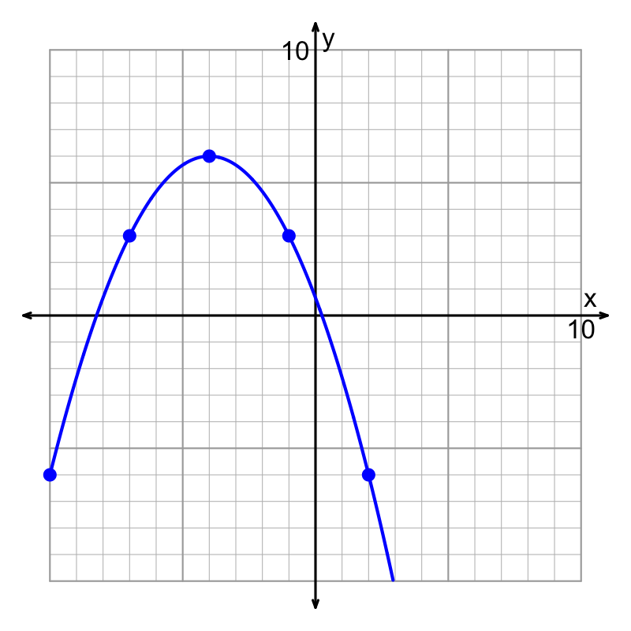

Find the parameters.

- $a=$
- $h=$
- $k=$

How many $x$-intercepts does the parabola have? (Some might not show on the graph.)

To find $a$, you might use [this reference](https://artockthedino.github.io/algtwo2026/u06/1218/Stretched_Parabolas_Reference.html). Notice, if $a$ is negative, the parabola faces down, and if $a$ is positive, the parabola faces up. If $|a|$ is bigger than 1, then the parent $y=x^2$ is stretched vertically. If $|a|$ is less than 1, then the parent $y=x^2$ is shrunk vertically. To find the exact value, you need to look at precisely where the curve intersects the lattice points.

To find $h$ and $k$, you can just find the coordinates of the vertex.

To determine the number of roots...

- If the vertex is on the $x$ axis, there is one root.
- If the parabola opens **up** and the vertex is **above** the $x$ axis, then 0 roots.
- If the parabola opens **down** and the vertex is **above** the $x$ axis, then 2 roots.
- If the parabola opens **up** and the vertex is **below** the $x$ axis, then 2 roots.
- If the parabola opens **down** and the vertex is **below** the $x$ axis, then 0 roots.

A parabola is randomly generated by randomly choosing parameters $a$, $h$, and $k$ in the vertex-form equation:

$$y~=~a(x-h)^2+k$$

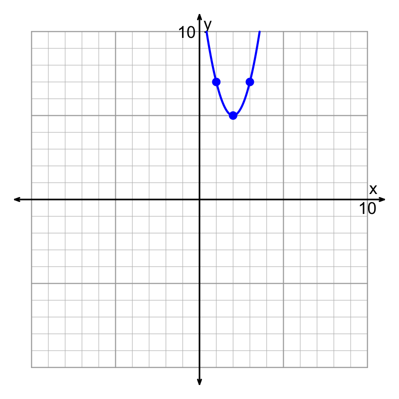

Find the parameters.

- $a=$
- $h=$
- $k=$

How many $x$-intercepts does the parabola have? (Some might not show on the graph.)

To find $a$, you might use [this reference](https://artockthedino.github.io/algtwo2026/u06/1218/Stretched_Parabolas_Reference.html). Notice, if $a$ is negative, the parabola faces down, and if $a$ is positive, the parabola faces up. If $|a|$ is bigger than 1, then the parent $y=x^2$ is stretched vertically. If $|a|$ is less than 1, then the parent $y=x^2$ is shrunk vertically. To find the exact value, you need to look at precisely where the curve intersects the lattice points.

To find $h$ and $k$, you can just find the coordinates of the vertex.

To determine the number of roots...

- If the vertex is on the $x$ axis, there is one root.
- If the parabola opens **up** and the vertex is **above** the $x$ axis, then 0 roots.
- If the parabola opens **down** and the vertex is **above** the $x$ axis, then 2 roots.
- If the parabola opens **up** and the vertex is **below** the $x$ axis, then 2 roots.
- If the parabola opens **down** and the vertex is **below** the $x$ axis, then 0 roots.

A parabola is randomly generated by randomly choosing parameters $a$, $h$, and $k$ in the vertex-form equation:

$$y~=~a(x-h)^2+k$$

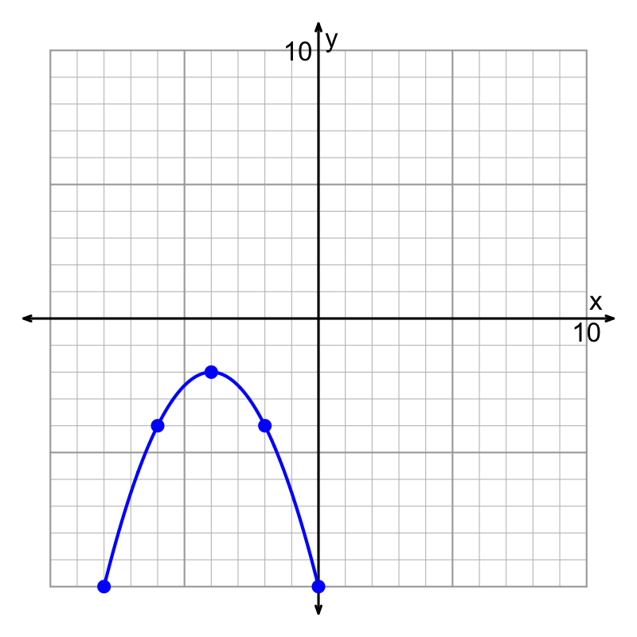

Find the parameters.

- $a=$
- $h=$
- $k=$

How many $x$-intercepts does the parabola have? (Some might not show on the graph.)

To find $a$, you might use [this reference](https://artockthedino.github.io/algtwo2026/u06/1218/Stretched_Parabolas_Reference.html). Notice, if $a$ is negative, the parabola faces down, and if $a$ is positive, the parabola faces up. If $|a|$ is bigger than 1, then the parent $y=x^2$ is stretched vertically. If $|a|$ is less than 1, then the parent $y=x^2$ is shrunk vertically. To find the exact value, you need to look at precisely where the curve intersects the lattice points.

To find $h$ and $k$, you can just find the coordinates of the vertex.

To determine the number of roots...

- If the vertex is on the $x$ axis, there is one root.
- If the parabola opens **up** and the vertex is **above** the $x$ axis, then 0 roots.
- If the parabola opens **down** and the vertex is **above** the $x$ axis, then 2 roots.
- If the parabola opens **up** and the vertex is **below** the $x$ axis, then 2 roots.
- If the parabola opens **down** and the vertex is **below** the $x$ axis, then 0 roots.

A parabola is randomly generated by randomly choosing parameters $a$, $h$, and $k$ in the vertex-form equation:

$$y~=~a(x-h)^2+k$$

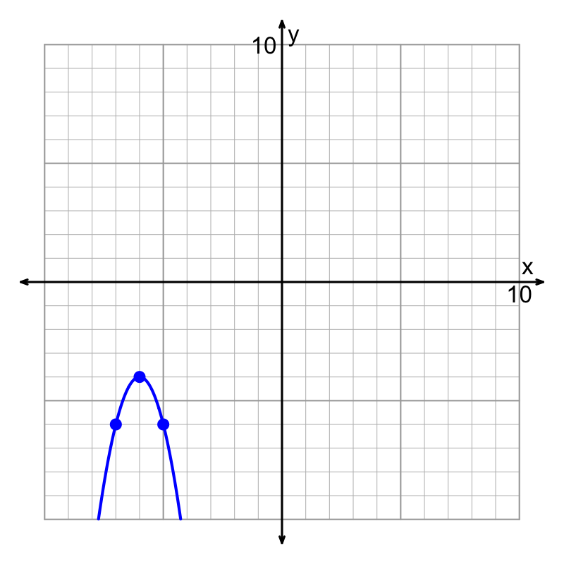

Find the parameters.

- $a=$
- $h=$
- $k=$

How many $x$-intercepts does the parabola have? (Some might not show on the graph.)

To find $a$, you might use [this reference](https://artockthedino.github.io/algtwo2026/u06/1218/Stretched_Parabolas_Reference.html). Notice, if $a$ is negative, the parabola faces down, and if $a$ is positive, the parabola faces up. If $|a|$ is bigger than 1, then the parent $y=x^2$ is stretched vertically. If $|a|$ is less than 1, then the parent $y=x^2$ is shrunk vertically. To find the exact value, you need to look at precisely where the curve intersects the lattice points.

To find $h$ and $k$, you can just find the coordinates of the vertex.

To determine the number of roots...

- If the vertex is on the $x$ axis, there is one root.
- If the parabola opens **up** and the vertex is **above** the $x$ axis, then 0 roots.
- If the parabola opens **down** and the vertex is **above** the $x$ axis, then 2 roots.
- If the parabola opens **up** and the vertex is **below** the $x$ axis, then 2 roots.
- If the parabola opens **down** and the vertex is **below** the $x$ axis, then 0 roots.

A parabola is randomly generated by randomly choosing parameters $a$, $h$, and $k$ in the vertex-form equation:

$$y~=~a(x-h)^2+k$$

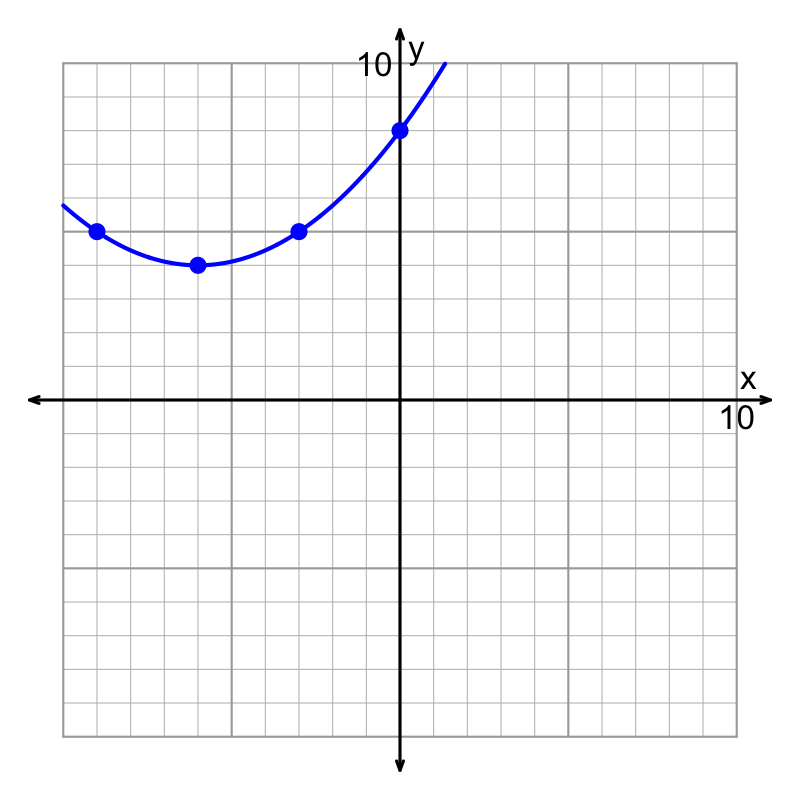

Find the parameters.

- $a=$
- $h=$
- $k=$

How many $x$-intercepts does the parabola have? (Some might not show on the graph.)

To find $a$, you might use [this reference](https://artockthedino.github.io/algtwo2026/u06/1218/Stretched_Parabolas_Reference.html). Notice, if $a$ is negative, the parabola faces down, and if $a$ is positive, the parabola faces up. If $|a|$ is bigger than 1, then the parent $y=x^2$ is stretched vertically. If $|a|$ is less than 1, then the parent $y=x^2$ is shrunk vertically. To find the exact value, you need to look at precisely where the curve intersects the lattice points.

To find $h$ and $k$, you can just find the coordinates of the vertex.

To determine the number of roots...

- If the vertex is on the $x$ axis, there is one root.
- If the parabola opens **up** and the vertex is **above** the $x$ axis, then 0 roots.
- If the parabola opens **down** and the vertex is **above** the $x$ axis, then 2 roots.
- If the parabola opens **up** and the vertex is **below** the $x$ axis, then 2 roots.
- If the parabola opens **down** and the vertex is **below** the $x$ axis, then 0 roots.

A parabola is randomly generated by randomly choosing parameters $a$, $h$, and $k$ in the vertex-form equation:

$$y~=~a(x-h)^2+k$$

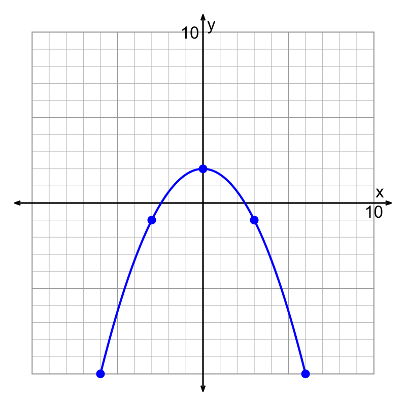

Find the parameters.

- $a=$
- $h=$
- $k=$

How many $x$-intercepts does the parabola have? (Some might not show on the graph.)

To find $a$, you might use [this reference](https://artockthedino.github.io/algtwo2026/u06/1218/Stretched_Parabolas_Reference.html). Notice, if $a$ is negative, the parabola faces down, and if $a$ is positive, the parabola faces up. If $|a|$ is bigger than 1, then the parent $y=x^2$ is stretched vertically. If $|a|$ is less than 1, then the parent $y=x^2$ is shrunk vertically. To find the exact value, you need to look at precisely where the curve intersects the lattice points.

To find $h$ and $k$, you can just find the coordinates of the vertex.

To determine the number of roots...

- If the vertex is on the $x$ axis, there is one root.
- If the parabola opens **up** and the vertex is **above** the $x$ axis, then 0 roots.
- If the parabola opens **down** and the vertex is **above** the $x$ axis, then 2 roots.
- If the parabola opens **up** and the vertex is **below** the $x$ axis, then 2 roots.
- If the parabola opens **down** and the vertex is **below** the $x$ axis, then 0 roots.

A quadratic function, with two [real](https://en.wikipedia.org/wiki/Real_number) [roots](https://en.wikipedia.org/wiki/Zero_of_a_function), is graphed below.

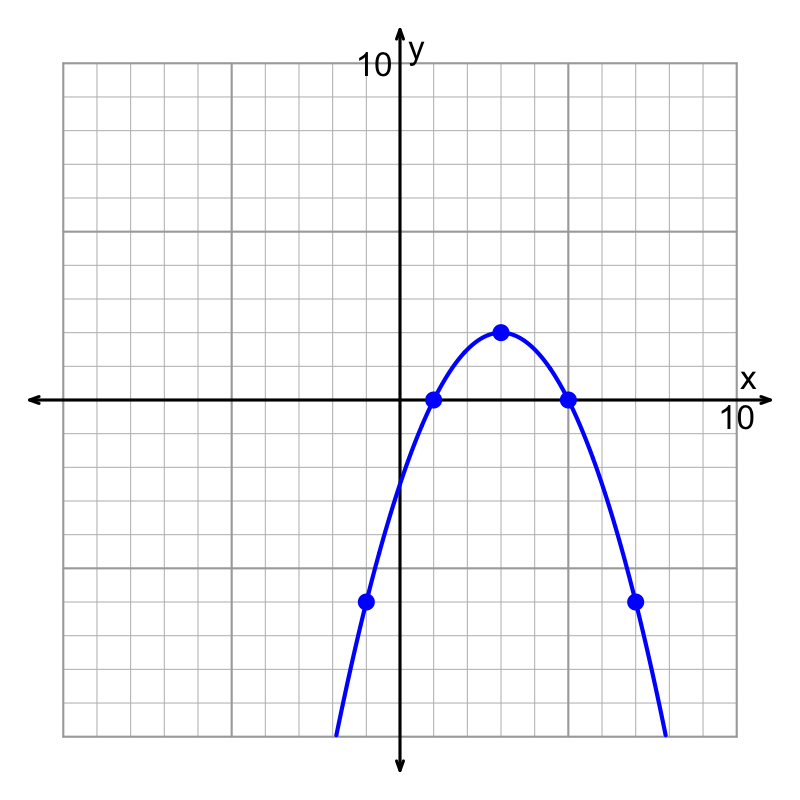

What equation represents the function in factored form?

$y=-2(x-{5})(x-{1})$$y=-2(x-{5})(x+{1})$$y=-2(x+{5})(x-{1})$$y=-2(x+{5})(x+{1})$$y=\frac{-1}{2}(x-{5})(x-{1})$$y=\frac{-1}{2}(x-{5})(x+{1})$$y=\frac{-1}{2}(x+{5})(x-{1})$$y=\frac{-1}{2}(x+{5})(x+{1})$$y=\frac{1}{2}(x-{5})(x-{1})$$y=\frac{1}{2}(x-{5})(x+{1})$$y=\frac{1}{2}(x+{5})(x-{1})$$y=\frac{1}{2}(x+{5})(x+{1})$$y=2(x-{5})(x-{1})$$y=2(x-{5})(x+{1})$$y=2(x+{5})(x-{1})$$y=2(x+{5})(x+{1})$

The correct answer is:
$$y=\frac{-1}{2}(x-{5})(x-{1})$$

You can determine $a$ by using [this reference sheet](https://artockthedino.github.io/algtwo2026/u06/1218/Stretched_Parabolas_Reference.html). You also need to remember that if $a<0$, then the parabola opens downward.

The roots are at $(1,0)$ and $(5,0)$. Thus, we could say $r=5$ and $s=1$ (or the other way around). We put those parameters into factored-form equation, $y=a(x-r)(x-s)$, to get...

$$y=\frac{-1}{2}(x-{5})(x-{1})$$

A quadratic function, with two [real](https://en.wikipedia.org/wiki/Real_number) [roots](https://en.wikipedia.org/wiki/Zero_of_a_function), is graphed below.

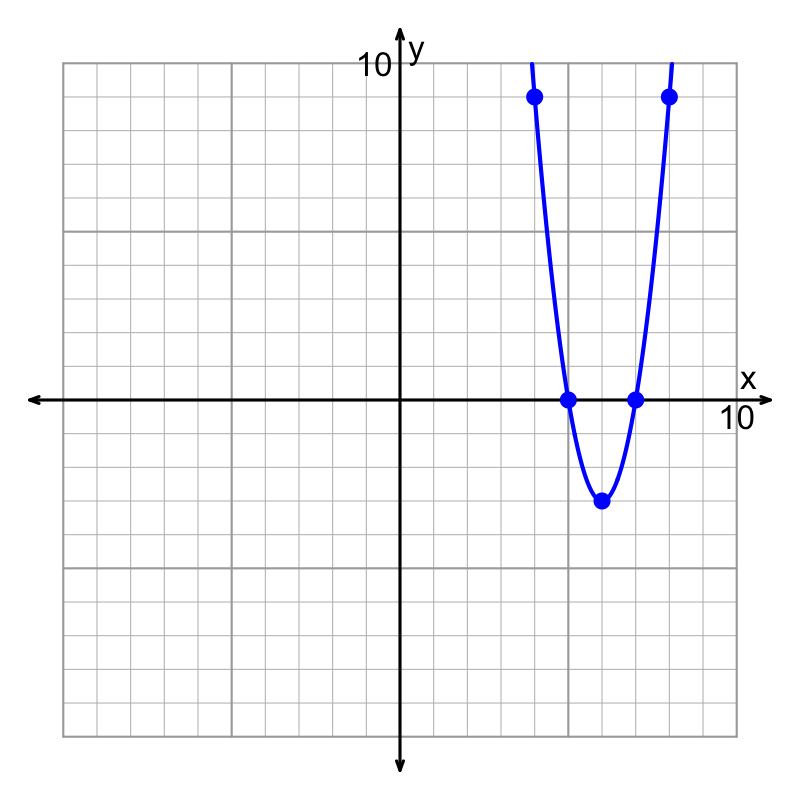

What equation represents the function in factored form?

$y=-2(x-{5})(x-{7})$$y=-2(x-{5})(x+{7})$$y=-2(x+{5})(x-{7})$$y=-2(x+{5})(x+{7})$$y=-3(x-{5})(x-{7})$$y=-3(x-{5})(x+{7})$$y=-3(x+{5})(x-{7})$$y=-3(x+{5})(x+{7})$$y=2(x-{5})(x-{7})$$y=2(x-{5})(x+{7})$$y=2(x+{5})(x-{7})$$y=2(x+{5})(x+{7})$$y=3(x-{5})(x-{7})$$y=3(x-{5})(x+{7})$$y=3(x+{5})(x-{7})$$y=3(x+{5})(x+{7})$

The correct answer is:
$$y=3(x-{5})(x-{7})$$

You can determine $a$ by using [this reference sheet](https://artockthedino.github.io/algtwo2026/u06/1218/Stretched_Parabolas_Reference.html). You also need to remember that if $a<0$, then the parabola opens downward.

The roots are at $(5,0)$ and $(7,0)$. Thus, we could say $r=5$ and $s=7$ (or the other way around). We put those parameters into factored-form equation, $y=a(x-r)(x-s)$, to get...

$$y=3(x-{5})(x-{7})$$

A quadratic function, with two [real](https://en.wikipedia.org/wiki/Real_number) [roots](https://en.wikipedia.org/wiki/Zero_of_a_function), is graphed below.

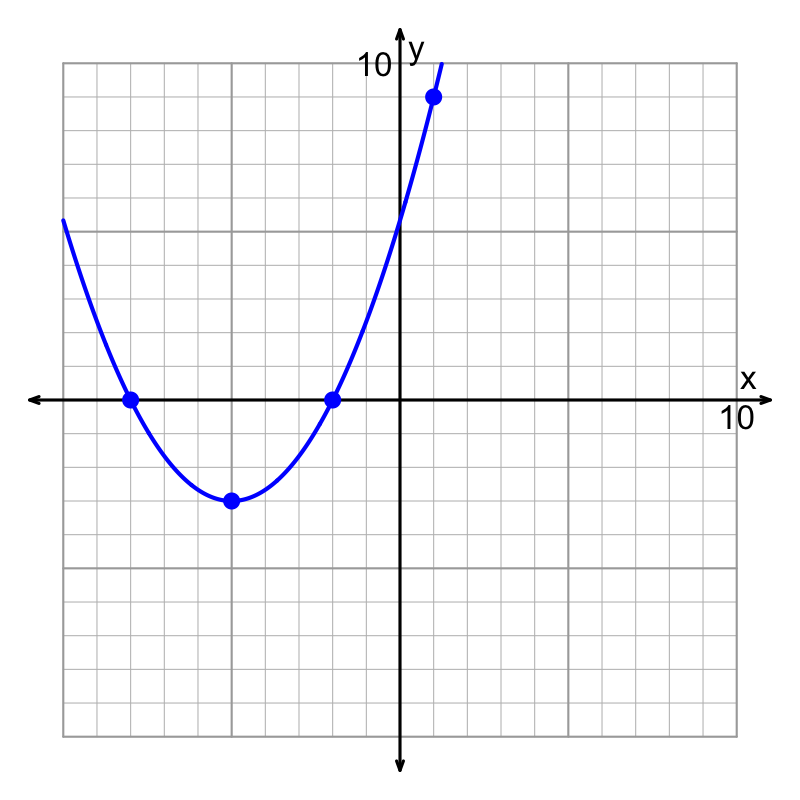

What equation represents the function in factored form?

$y=\frac{-1}{3}(x-{2})(x-{8})$$y=\frac{-1}{3}(x-{2})(x+{8})$$y=\frac{-1}{3}(x+{2})(x-{8})$$y=\frac{-1}{3}(x+{2})(x+{8})$$y=\frac{-1}{9}(x-{2})(x-{8})$$y=\frac{-1}{9}(x-{2})(x+{8})$$y=\frac{-1}{9}(x+{2})(x-{8})$$y=\frac{-1}{9}(x+{2})(x+{8})$$y=\frac{1}{3}(x-{2})(x-{8})$$y=\frac{1}{3}(x-{2})(x+{8})$$y=\frac{1}{3}(x+{2})(x-{8})$$y=\frac{1}{3}(x+{2})(x+{8})$$y=\frac{1}{9}(x-{2})(x-{8})$$y=\frac{1}{9}(x-{2})(x+{8})$$y=\frac{1}{9}(x+{2})(x-{8})$$y=\frac{1}{9}(x+{2})(x+{8})$

The correct answer is:
$$y=\frac{1}{3}(x+{2})(x+{8})$$

You can determine $a$ by using [this reference sheet](https://artockthedino.github.io/algtwo2026/u06/1218/Stretched_Parabolas_Reference.html). You also need to remember that if $a<0$, then the parabola opens downward.

The roots are at $(-8,0)$ and $(-2,0)$. Thus, we could say $r=-2$ and $s=-8$ (or the other way around). We put those parameters into factored-form equation, $y=a(x-r)(x-s)$, to get...

$$y=\frac{1}{3}(x+{2})(x+{8})$$

A quadratic function, with two [real](https://en.wikipedia.org/wiki/Real_number) [roots](https://en.wikipedia.org/wiki/Zero_of_a_function), is graphed below.

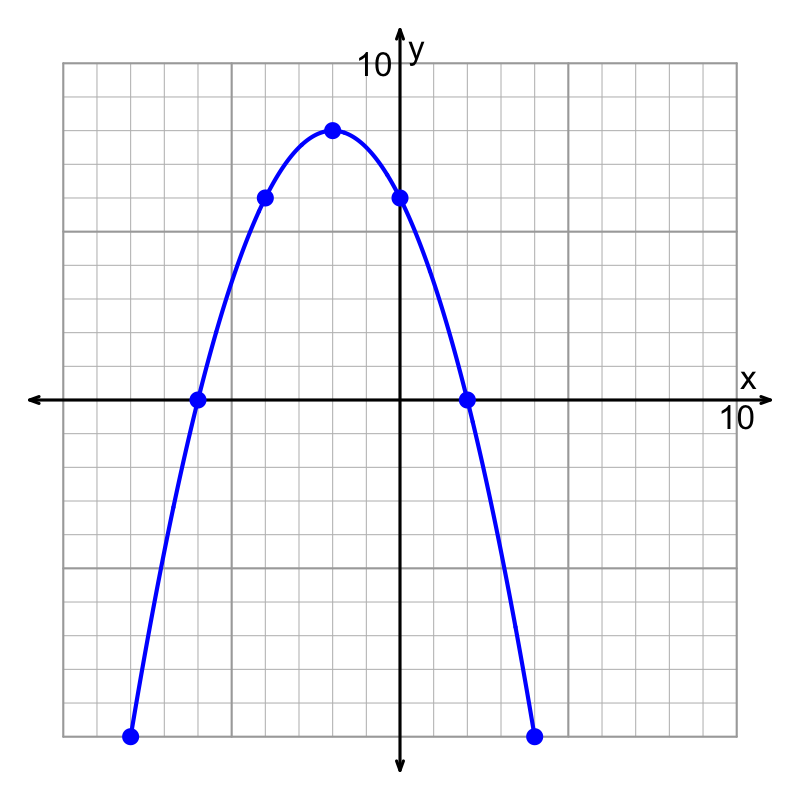

What equation represents the function in factored form?

$y=\frac{-1}{2}(x-{2})(x-{6})$$y=\frac{-1}{2}(x-{2})(x+{6})$$y=\frac{-1}{2}(x+{2})(x-{6})$$y=\frac{-1}{2}(x+{2})(x+{6})$$y=\frac{-1}{4}(x-{2})(x-{6})$$y=\frac{-1}{4}(x-{2})(x+{6})$$y=\frac{-1}{4}(x+{2})(x-{6})$$y=\frac{-1}{4}(x+{2})(x+{6})$$y=\frac{1}{2}(x-{2})(x-{6})$$y=\frac{1}{2}(x-{2})(x+{6})$$y=\frac{1}{2}(x+{2})(x-{6})$$y=\frac{1}{2}(x+{2})(x+{6})$$y=\frac{1}{4}(x-{2})(x-{6})$$y=\frac{1}{4}(x-{2})(x+{6})$$y=\frac{1}{4}(x+{2})(x-{6})$$y=\frac{1}{4}(x+{2})(x+{6})$

The correct answer is:
$$y=\frac{-1}{2}(x-{2})(x+{6})$$

You can determine $a$ by using [this reference sheet](https://artockthedino.github.io/algtwo2026/u06/1218/Stretched_Parabolas_Reference.html). You also need to remember that if $a<0$, then the parabola opens downward.

The roots are at $(-6,0)$ and $(2,0)$. Thus, we could say $r=2$ and $s=-6$ (or the other way around). We put those parameters into factored-form equation, $y=a(x-r)(x-s)$, to get...

$$y=\frac{-1}{2}(x-{2})(x+{6})$$

A quadratic function, with two [real](https://en.wikipedia.org/wiki/Real_number) [roots](https://en.wikipedia.org/wiki/Zero_of_a_function), is graphed below.

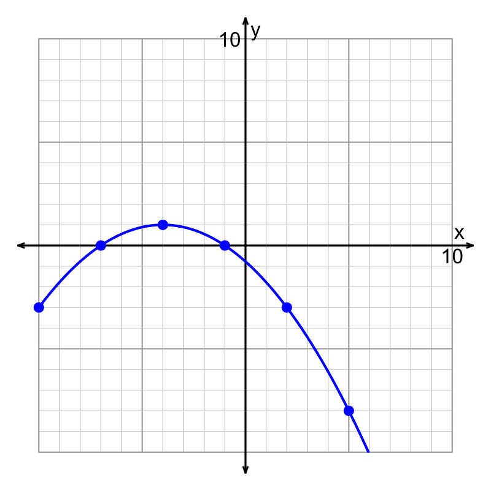

What equation represents the function in factored form?

$y=-2(x-{1})(x-{7})$$y=-2(x-{1})(x+{7})$$y=-2(x+{1})(x-{7})$$y=-2(x+{1})(x+{7})$$y=\frac{-1}{9}(x-{1})(x-{7})$$y=\frac{-1}{9}(x-{1})(x+{7})$$y=\frac{-1}{9}(x+{1})(x-{7})$$y=\frac{-1}{9}(x+{1})(x+{7})$$y=\frac{1}{9}(x-{1})(x-{7})$$y=\frac{1}{9}(x-{1})(x+{7})$$y=\frac{1}{9}(x+{1})(x-{7})$$y=\frac{1}{9}(x+{1})(x+{7})$$y=2(x-{1})(x-{7})$$y=2(x-{1})(x+{7})$$y=2(x+{1})(x-{7})$$y=2(x+{1})(x+{7})$

The correct answer is:
$$y=\frac{-1}{9}(x+{1})(x+{7})$$

You can determine $a$ by using [this reference sheet](https://artockthedino.github.io/algtwo2026/u06/1218/Stretched_Parabolas_Reference.html). You also need to remember that if $a<0$, then the parabola opens downward.

The roots are at $(-7,0)$ and $(-1,0)$. Thus, we could say $r=-1$ and $s=-7$ (or the other way around). We put those parameters into factored-form equation, $y=a(x-r)(x-s)$, to get...

$$y=\frac{-1}{9}(x+{1})(x+{7})$$

A quadratic function, with two [real](https://en.wikipedia.org/wiki/Real_number) [roots](https://en.wikipedia.org/wiki/Zero_of_a_function), is graphed below.

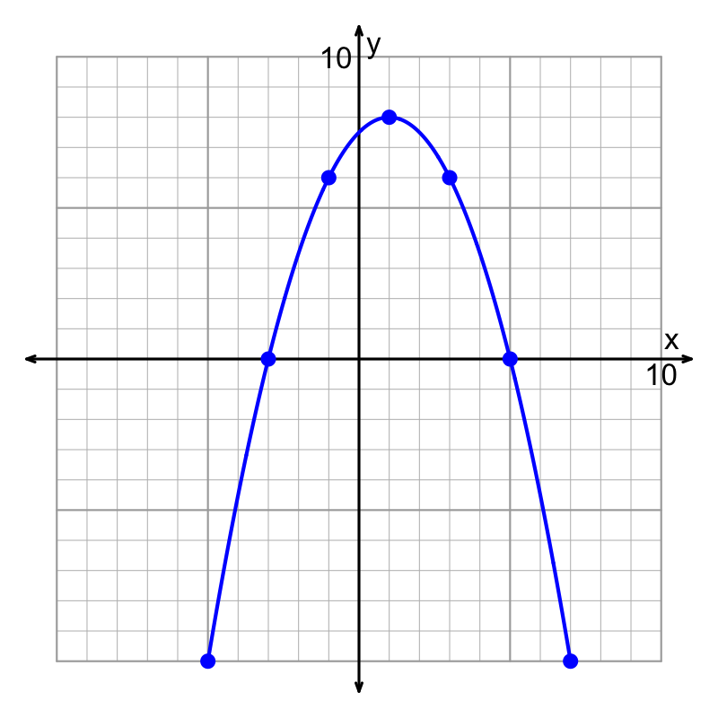

What equation represents the function in factored form?

$y=\frac{-1}{2}(x-{3})(x-{5})$$y=\frac{-1}{2}(x-{3})(x+{5})$$y=\frac{-1}{2}(x+{3})(x-{5})$$y=\frac{-1}{2}(x+{3})(x+{5})$$y=\frac{-1}{9}(x-{3})(x-{5})$$y=\frac{-1}{9}(x-{3})(x+{5})$$y=\frac{-1}{9}(x+{3})(x-{5})$$y=\frac{-1}{9}(x+{3})(x+{5})$$y=\frac{1}{2}(x-{3})(x-{5})$$y=\frac{1}{2}(x-{3})(x+{5})$$y=\frac{1}{2}(x+{3})(x-{5})$$y=\frac{1}{2}(x+{3})(x+{5})$$y=\frac{1}{9}(x-{3})(x-{5})$$y=\frac{1}{9}(x-{3})(x+{5})$$y=\frac{1}{9}(x+{3})(x-{5})$$y=\frac{1}{9}(x+{3})(x+{5})$

The correct answer is:
$$y=\frac{-1}{2}(x+{3})(x-{5})$$

You can determine $a$ by using [this reference sheet](https://artockthedino.github.io/algtwo2026/u06/1218/Stretched_Parabolas_Reference.html). You also need to remember that if $a<0$, then the parabola opens downward.

The roots are at $(-3,0)$ and $(5,0)$. Thus, we could say $r=-3$ and $s=5$ (or the other way around). We put those parameters into factored-form equation, $y=a(x-r)(x-s)$, to get...

$$y=\frac{-1}{2}(x+{3})(x-{5})$$

When $\sqrt{275}$ is simplified, it can be expressed as $p\sqrt{m}$, where $p$ and $m$ are both positive integers. Find $p$ and $m$.

$p=$

$m=$

Start with the given expression.
$$\sqrt{275}$$
I recommend prime factorization.
$$\sqrt{5\cdot5\cdot11}$$

Every pair of matching factors under the radical can be replaced with a single factor in front of the radical. More formally, we can apply the following 2 rules:

1. Square roots distribute over multiplication. $\sqrt{x\cdot y}\equiv \sqrt{x}\cdot\sqrt{y}$
2. The square root of a squared number is equivalent to the absolute value of that number. $\sqrt{z^2}~\equiv~|z|$

Applying those rules (or "bringing out repeating factors") leads to:

$$5\sqrt{11}$$

If necessary, evaluate any products to simplify.

$$5\sqrt{11}$$

So, $p=5$ and $m=11$.

When $\sqrt{108}$ is simplified, it can be expressed as $p\sqrt{m}$, where $p$ and $m$ are both positive integers. Find $p$ and $m$.

$p=$

$m=$

Start with the given expression.
$$\sqrt{108}$$
I recommend prime factorization.
$$\sqrt{2\cdot2\cdot3\cdot3\cdot3}$$

Every pair of matching factors under the radical can be replaced with a single factor in front of the radical. More formally, we can apply the following 2 rules:

1. Square roots distribute over multiplication. $\sqrt{x\cdot y}\equiv \sqrt{x}\cdot\sqrt{y}$
2. The square root of a squared number is equivalent to the absolute value of that number. $\sqrt{z^2}~\equiv~|z|$

Applying those rules (or "bringing out repeating factors") leads to:

$$2\cdot3\sqrt{3}$$

If necessary, evaluate any products to simplify.

$$6\sqrt{3}$$

So, $p=6$ and $m=3$.

When $\sqrt{180}$ is simplified, it can be expressed as $p\sqrt{m}$, where $p$ and $m$ are both positive integers. Find $p$ and $m$.

$p=$

$m=$

Start with the given expression.
$$\sqrt{180}$$
I recommend prime factorization.
$$\sqrt{2\cdot2\cdot3\cdot3\cdot5}$$

Every pair of matching factors under the radical can be replaced with a single factor in front of the radical. More formally, we can apply the following 2 rules:

1. Square roots distribute over multiplication. $\sqrt{x\cdot y}\equiv \sqrt{x}\cdot\sqrt{y}$
2. The square root of a squared number is equivalent to the absolute value of that number. $\sqrt{z^2}~\equiv~|z|$

Applying those rules (or "bringing out repeating factors") leads to:

$$2\cdot3\sqrt{5}$$

If necessary, evaluate any products to simplify.

$$6\sqrt{5}$$

So, $p=6$ and $m=5$.

When $\sqrt{40}$ is simplified, it can be expressed as $p\sqrt{m}$, where $p$ and $m$ are both positive integers. Find $p$ and $m$.

$p=$

$m=$

Start with the given expression.
$$\sqrt{40}$$
I recommend prime factorization.
$$\sqrt{2\cdot2\cdot2\cdot5}$$

Every pair of matching factors under the radical can be replaced with a single factor in front of the radical. More formally, we can apply the following 2 rules:

1. Square roots distribute over multiplication. $\sqrt{x\cdot y}\equiv \sqrt{x}\cdot\sqrt{y}$
2. The square root of a squared number is equivalent to the absolute value of that number. $\sqrt{z^2}~\equiv~|z|$

Applying those rules (or "bringing out repeating factors") leads to:

$$2\sqrt{2\cdot5}$$

If necessary, evaluate any products to simplify.

$$2\sqrt{10}$$

So, $p=2$ and $m=10$.

When $\sqrt{45}$ is simplified, it can be expressed as $p\sqrt{m}$, where $p$ and $m$ are both positive integers. Find $p$ and $m$.

$p=$

$m=$

Start with the given expression.
$$\sqrt{45}$$
I recommend prime factorization.
$$\sqrt{3\cdot3\cdot5}$$

Every pair of matching factors under the radical can be replaced with a single factor in front of the radical. More formally, we can apply the following 2 rules:

1. Square roots distribute over multiplication. $\sqrt{x\cdot y}\equiv \sqrt{x}\cdot\sqrt{y}$
2. The square root of a squared number is equivalent to the absolute value of that number. $\sqrt{z^2}~\equiv~|z|$

Applying those rules (or "bringing out repeating factors") leads to:

$$3\sqrt{5}$$

If necessary, evaluate any products to simplify.

$$3\sqrt{5}$$

So, $p=3$ and $m=5$.

When $\sqrt{40}$ is simplified, it can be expressed as $p\sqrt{m}$, where $p$ and $m$ are both positive integers. Find $p$ and $m$.

$p=$

$m=$

Start with the given expression.
$$\sqrt{40}$$
I recommend prime factorization.
$$\sqrt{2\cdot2\cdot2\cdot5}$$

Every pair of matching factors under the radical can be replaced with a single factor in front of the radical. More formally, we can apply the following 2 rules:

1. Square roots distribute over multiplication. $\sqrt{x\cdot y}\equiv \sqrt{x}\cdot\sqrt{y}$
2. The square root of a squared number is equivalent to the absolute value of that number. $\sqrt{z^2}~\equiv~|z|$

Applying those rules (or "bringing out repeating factors") leads to:

$$2\sqrt{2\cdot5}$$

If necessary, evaluate any products to simplify.

$$2\sqrt{10}$$

So, $p=2$ and $m=10$.

Jordan is selling widgets. Each widget costs Jordan $0.50 to produce. Per week, the number of widgets ($w$) Jordan sells is a linear function of the price ($x$) Jordan charges per widget.
$$w=5800-3625x$$

Thus, the profit ($P$) is also a function of $x$.

$$P=(x-0.50)\cdot(5800-3625x)$$

If Jordan wishes to maximize profit, what price should he charge per widget?

$x_{\text{optimal}}~=~?$

We can start by expanding (by FOIL or box) the profit function.

$$P=(x-0.50)\cdot(5800-3625x)$$

$$P=5800x-3625x^2-2900+1812.5x$$

Combine like terms, and put into standard order.

$$P=-3625x^2+7612.5x-2900$$

Notice if we graphed this function, it would be a downward facing parabola. Thus, the vertex would represent the maximizing of profit. Because the question asks for the optimal price, we need to find $h$.

$$h=\frac{-b}{2a}$$

$$h=\frac{-7612.5}{2(-3625)}$$

$$h=1.05$$

Thus, $x_{\text{optimal}}=1.05$, and so Jordan should charge $1.05 per widget.

Jordan is selling widgets. Each widget costs Jordan $9.14 to produce. Per week, the number of widgets ($w$) Jordan sells is a linear function of the price ($x$) Jordan charges per widget.
$$w=7600-76x$$

Thus, the profit ($P$) is also a function of $x$.

$$P=(x-9.14)\cdot(7600-76x)$$

If Jordan wishes to maximize profit, what price should he charge per widget?

$x_{\text{optimal}}~=~?$

We can start by expanding (by FOIL or box) the profit function.

$$P=(x-9.14)\cdot(7600-76x)$$

$$P=7600x-76x^2-69464+694.64x$$

Combine like terms, and put into standard order.

$$P=-76x^2+8294.64x-69464$$

Notice if we graphed this function, it would be a downward facing parabola. Thus, the vertex would represent the maximizing of profit. Because the question asks for the optimal price, we need to find $h$.

$$h=\frac{-b}{2a}$$

$$h=\frac{-8294.64}{2(-76)}$$

$$h=54.57$$

Thus, $x_{\text{optimal}}=54.57$, and so Jordan should charge $54.57 per widget.

Jordan is selling widgets. Each widget costs Jordan $0.18 to produce. Per week, the number of widgets ($w$) Jordan sells is a linear function of the price ($x$) Jordan charges per widget.
$$w=5000-6250x$$

Thus, the profit ($P$) is also a function of $x$.

$$P=(x-0.18)\cdot(5000-6250x)$$

If Jordan wishes to maximize profit, what price should he charge per widget?

$x_{\text{optimal}}~=~?$

We can start by expanding (by FOIL or box) the profit function.

$$P=(x-0.18)\cdot(5000-6250x)$$

$$P=5000x-6250x^2-900+1125x$$

Combine like terms, and put into standard order.

$$P=-6250x^2+6125x-900$$

Notice if we graphed this function, it would be a downward facing parabola. Thus, the vertex would represent the maximizing of profit. Because the question asks for the optimal price, we need to find $h$.

$$h=\frac{-b}{2a}$$

$$h=\frac{-6125}{2(-6250)}$$

$$h=0.49$$

Thus, $x_{\text{optimal}}=0.49$, and so Jordan should charge $0.49 per widget.

Jordan is selling widgets. Each widget costs Jordan $1.12 to produce. Per week, the number of widgets ($w$) Jordan sells is a linear function of the price ($x$) Jordan charges per widget.
$$w=6200-1000x$$

Thus, the profit ($P$) is also a function of $x$.

$$P=(x-1.12)\cdot(6200-1000x)$$

If Jordan wishes to maximize profit, what price should he charge per widget?

$x_{\text{optimal}}~=~?$

We can start by expanding (by FOIL or box) the profit function.

$$P=(x-1.12)\cdot(6200-1000x)$$

$$P=6200x-1000x^2-6944+1120x$$

Combine like terms, and put into standard order.

$$P=-1000x^2+7320x-6944$$

Notice if we graphed this function, it would be a downward facing parabola. Thus, the vertex would represent the maximizing of profit. Because the question asks for the optimal price, we need to find $h$.

$$h=\frac{-b}{2a}$$

$$h=\frac{-7320}{2(-1000)}$$

$$h=3.66$$

Thus, $x_{\text{optimal}}=3.66$, and so Jordan should charge $3.66 per widget.

Jordan is selling widgets. Each widget costs Jordan $0.34 to produce. Per week, the number of widgets ($w$) Jordan sells is a linear function of the price ($x$) Jordan charges per widget.
$$w=6200-5000x$$

Thus, the profit ($P$) is also a function of $x$.

$$P=(x-0.34)\cdot(6200-5000x)$$

If Jordan wishes to maximize profit, what price should he charge per widget?

$x_{\text{optimal}}~=~?$

We can start by expanding (by FOIL or box) the profit function.

$$P=(x-0.34)\cdot(6200-5000x)$$

$$P=6200x-5000x^2-2108+1700x$$

Combine like terms, and put into standard order.

$$P=-5000x^2+7900x-2108$$

Notice if we graphed this function, it would be a downward facing parabola. Thus, the vertex would represent the maximizing of profit. Because the question asks for the optimal price, we need to find $h$.

$$h=\frac{-b}{2a}$$

$$h=\frac{-7900}{2(-5000)}$$

$$h=0.79$$

Thus, $x_{\text{optimal}}=0.79$, and so Jordan should charge $0.79 per widget.

Jordan is selling widgets. Each widget costs Jordan $0.02 to produce. Per week, the number of widgets ($w$) Jordan sells is a linear function of the price ($x$) Jordan charges per widget.
$$w=5700-19000x$$

Thus, the profit ($P$) is also a function of $x$.

$$P=(x-0.02)\cdot(5700-19000x)$$

If Jordan wishes to maximize profit, what price should he charge per widget?

$x_{\text{optimal}}~=~?$

We can start by expanding (by FOIL or box) the profit function.

$$P=(x-0.02)\cdot(5700-19000x)$$

$$P=5700x-19000x^2-114+380x$$

Combine like terms, and put into standard order.

$$P=-19000x^2+6080x-114$$

Notice if we graphed this function, it would be a downward facing parabola. Thus, the vertex would represent the maximizing of profit. Because the question asks for the optimal price, we need to find $h$.

$$h=\frac{-b}{2a}$$

$$h=\frac{-6080}{2(-19000)}$$

$$h=0.16$$

Thus, $x_{\text{optimal}}=0.16$, and so Jordan should charge $0.16 per widget.

Consider the quadratic function graphed below.

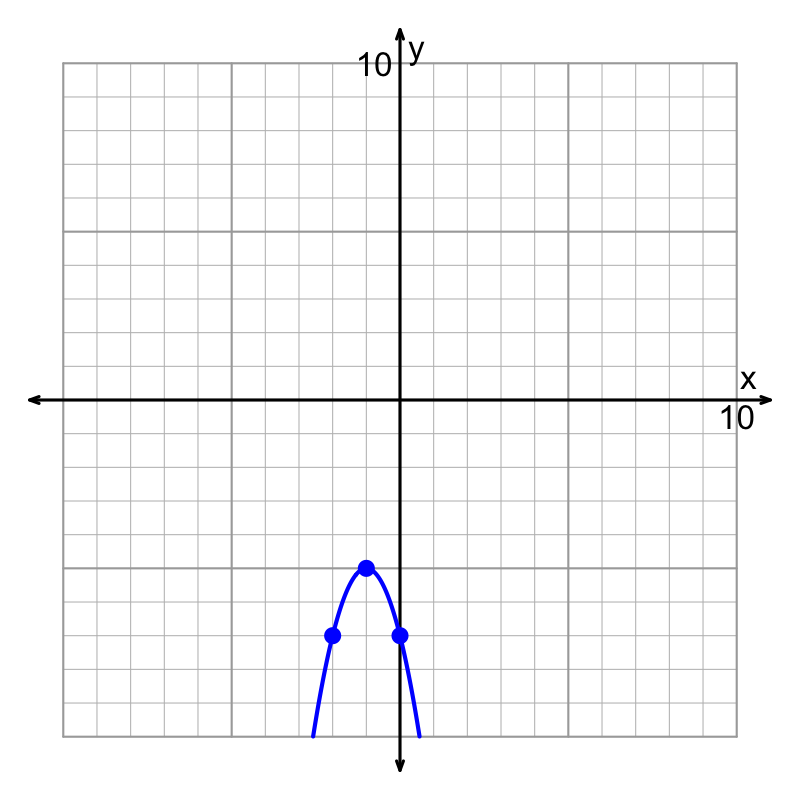

Find parameters $a$, $b$, and $c$, such that the above curve represents $y=ax^2+bx+c$.

- $a=$
- $b=$
- $c=$

First, [based on the spacing of lattice-point intersections near the vertex](https://artockthedino.github.io/algtwo2026/u06/1218/Stretched_Parabolas_Reference.html), and also the up/down orientation, we can determine $a$.

$$a~=~-2$$

Next, identify the location of the vertex is $(-1,-5)$, so $h=-1$. We know that $h=\frac{-b}{2a}$, so with a bit of algebra, we also know that $b=-2ah$.

$$b~=~-2(-2)(-1)$$
$$b~=~-4$$

Lastly, getting $c$ is easy. Notice, if $x=0$, then $y=c$. Thus, we just need to find the $y$ intercept to get $c$.

$$c=-7$$

The function:

$$y={-2}x^{2}-{4}x-{7}$$

Consider the quadratic function graphed below.

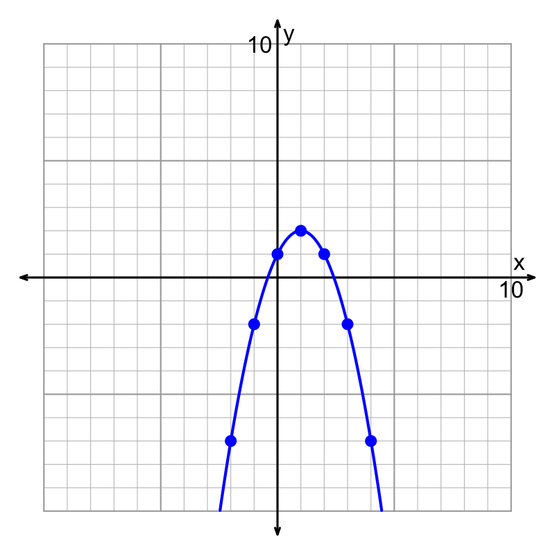

Find parameters $a$, $b$, and $c$, such that the above curve represents $y=ax^2+bx+c$.

- $a=$
- $b=$
- $c=$

First, [based on the spacing of lattice-point intersections near the vertex](https://artockthedino.github.io/algtwo2026/u06/1218/Stretched_Parabolas_Reference.html), and also the up/down orientation, we can determine $a$.

$$a~=~-1$$

Next, identify the location of the vertex is $(1,2)$, so $h=1$. We know that $h=\frac{-b}{2a}$, so with a bit of algebra, we also know that $b=-2ah$.

$$b~=~-2(-1)(1)$$
$$b~=~2$$

Lastly, getting $c$ is easy. Notice, if $x=0$, then $y=c$. Thus, we just need to find the $y$ intercept to get $c$.

$$c=1$$

The function:

$$y=-x^{2}+{2}x+{1}$$

Consider the quadratic function graphed below.

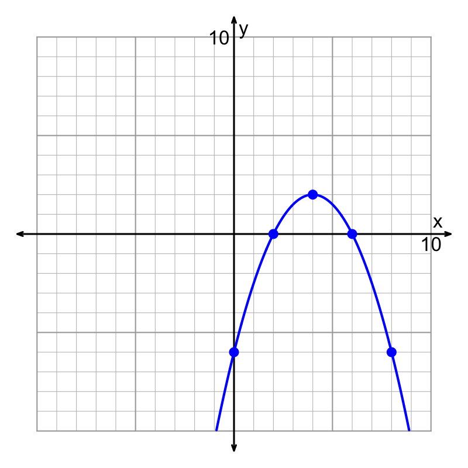

Find parameters $a$, $b$, and $c$, such that the above curve represents $y=ax^2+bx+c$.

- $a=$
- $b=$
- $c=$

First, [based on the spacing of lattice-point intersections near the vertex](https://artockthedino.github.io/algtwo2026/u06/1218/Stretched_Parabolas_Reference.html), and also the up/down orientation, we can determine $a$.

$$a~=~\frac{-1}{2}$$

Next, identify the location of the vertex is $(4,2)$, so $h=4$. We know that $h=\frac{-b}{2a}$, so with a bit of algebra, we also know that $b=-2ah$.

$$b~=~-2(-1/2)(4)$$
$$b~=~4$$

Lastly, getting $c$ is easy. Notice, if $x=0$, then $y=c$. Thus, we just need to find the $y$ intercept to get $c$.

$$c=-6$$

The function:

$$y={\frac{-1}{2}}x^{2}+{4}x-{6}$$

Consider the quadratic function graphed below.

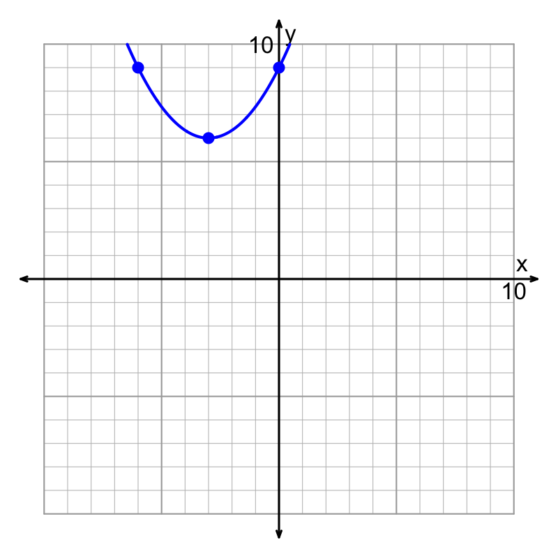

Find parameters $a$, $b$, and $c$, such that the above curve represents $y=ax^2+bx+c$.

- $a=$
- $b=$
- $c=$

First, [based on the spacing of lattice-point intersections near the vertex](https://artockthedino.github.io/algtwo2026/u06/1218/Stretched_Parabolas_Reference.html), and also the up/down orientation, we can determine $a$.

$$a~=~\frac{1}{3}$$

Next, identify the location of the vertex is $(-3,6)$, so $h=-3$. We know that $h=\frac{-b}{2a}$, so with a bit of algebra, we also know that $b=-2ah$.

$$b~=~-2(1/3)(-3)$$
$$b~=~2$$

Lastly, getting $c$ is easy. Notice, if $x=0$, then $y=c$. Thus, we just need to find the $y$ intercept to get $c$.

$$c=9$$

The function:

$$y={\frac{1}{3}}x^{2}+{2}x+{9}$$

Consider the quadratic function graphed below.

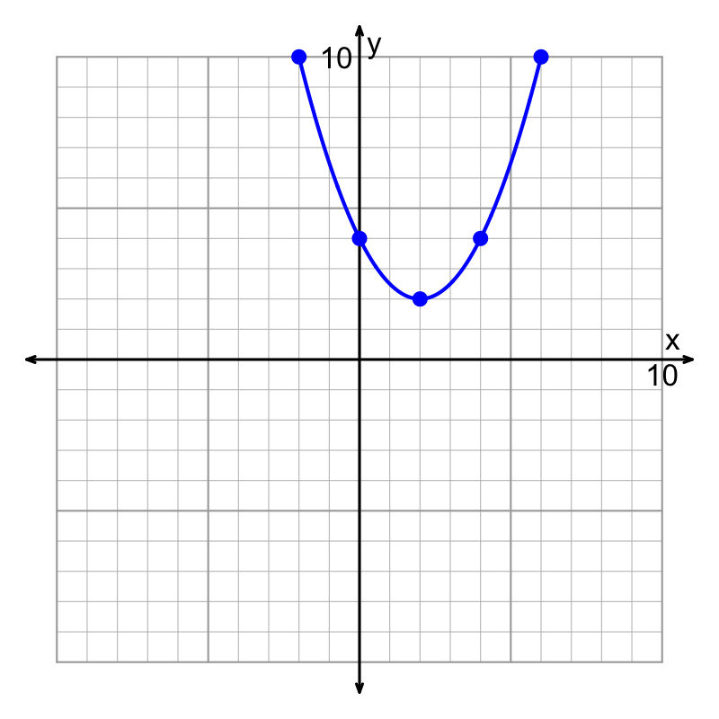

Find parameters $a$, $b$, and $c$, such that the above curve represents $y=ax^2+bx+c$.

- $a=$
- $b=$
- $c=$

First, [based on the spacing of lattice-point intersections near the vertex](https://artockthedino.github.io/algtwo2026/u06/1218/Stretched_Parabolas_Reference.html), and also the up/down orientation, we can determine $a$.

$$a~=~\frac{1}{2}$$

Next, identify the location of the vertex is $(2,2)$, so $h=2$. We know that $h=\frac{-b}{2a}$, so with a bit of algebra, we also know that $b=-2ah$.

$$b~=~-2(1/2)(2)$$
$$b~=~-2$$

Lastly, getting $c$ is easy. Notice, if $x=0$, then $y=c$. Thus, we just need to find the $y$ intercept to get $c$.

$$c=4$$

The function:

$$y={\frac{1}{2}}x^{2}-{2}x+{4}$$

Consider the quadratic function graphed below.

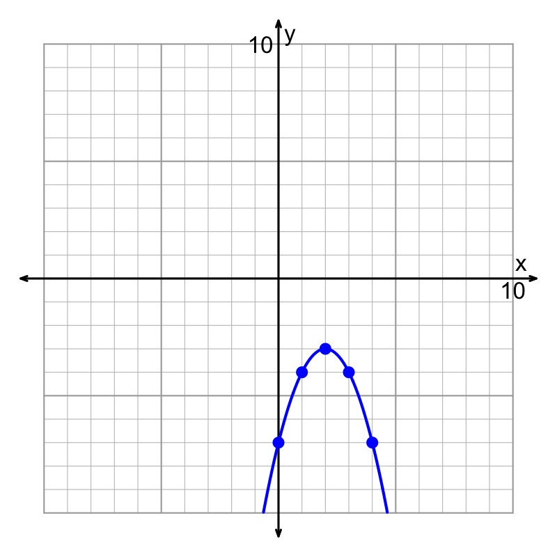

Find parameters $a$, $b$, and $c$, such that the above curve represents $y=ax^2+bx+c$.

- $a=$
- $b=$
- $c=$

First, [based on the spacing of lattice-point intersections near the vertex](https://artockthedino.github.io/algtwo2026/u06/1218/Stretched_Parabolas_Reference.html), and also the up/down orientation, we can determine $a$.

$$a~=~-1$$

Next, identify the location of the vertex is $(2,-3)$, so $h=2$. We know that $h=\frac{-b}{2a}$, so with a bit of algebra, we also know that $b=-2ah$.

$$b~=~-2(-1)(2)$$
$$b~=~4$$

Lastly, getting $c$ is easy. Notice, if $x=0$, then $y=c$. Thus, we just need to find the $y$ intercept to get $c$.

$$c=-7$$

The function:

$$y=-x^{2}+{4}x-{7}$$

A standard-form quadratic function has three parameters $a$, $b$, and $c$:

$$y=ax^2+bx+c$$

An important quantity we can calculate is the [discriminant](https://en.wikipedia.org/wiki/Quadratic_equation#Discriminant).

$$D~=~b^2-4ac$$

Calculate the discriminant of the following quadratic function:

$$y~=~{13}x^{2}-{2}x-{3}$$

Identify the coefficients.

$$a=13$$
$$b=-2$$
$$c=-3$$

Use the formula for the disciminant.

$$D=(-2)^2-4(13)(-3)$$

$$D=160$$

The discriminant, $D=160$, is positive, so there are two $x$-intercepts.

A standard-form quadratic function has three parameters $a$, $b$, and $c$:

$$y=ax^2+bx+c$$

An important quantity we can calculate is the [discriminant](https://en.wikipedia.org/wiki/Quadratic_equation#Discriminant).

$$D~=~b^2-4ac$$

Calculate the discriminant of the following quadratic function:

$$y~=~{2}x^{2}+{9}x+{9}$$

Identify the coefficients.

$$a=2$$
$$b=9$$
$$c=9$$

Use the formula for the disciminant.

$$D=(9)^2-4(2)(9)$$

$$D=9$$

The discriminant, $D=9$, is positive, so there are two $x$-intercepts.

A standard-form quadratic function has three parameters $a$, $b$, and $c$:

$$y=ax^2+bx+c$$

An important quantity we can calculate is the [discriminant](https://en.wikipedia.org/wiki/Quadratic_equation#Discriminant).

$$D~=~b^2-4ac$$

Calculate the discriminant of the following quadratic function:

$$y~=~{-2}x^{2}-{5}x+{6}$$

Identify the coefficients.

$$a=-2$$
$$b=-5$$
$$c=6$$

Use the formula for the disciminant.

$$D=(-5)^2-4(-2)(6)$$

$$D=73$$

The discriminant, $D=73$, is positive, so there are two $x$-intercepts.

A standard-form quadratic function has three parameters $a$, $b$, and $c$:

$$y=ax^2+bx+c$$

An important quantity we can calculate is the [discriminant](https://en.wikipedia.org/wiki/Quadratic_equation#Discriminant).

$$D~=~b^2-4ac$$

Calculate the discriminant of the following quadratic function:

$$y~=~{-16}x^{2}-{16}x-{12}$$

Identify the coefficients.

$$a=-16$$
$$b=-16$$
$$c=-12$$

Use the formula for the disciminant.

$$D=(-16)^2-4(-16)(-12)$$

$$D=-512$$

The discriminant, $D=-512$, is negative, so there are no $x$-intercepts.

A standard-form quadratic function has three parameters $a$, $b$, and $c$:

$$y=ax^2+bx+c$$

An important quantity we can calculate is the [discriminant](https://en.wikipedia.org/wiki/Quadratic_equation#Discriminant).

$$D~=~b^2-4ac$$

Calculate the discriminant of the following quadratic function:

$$y~=~{-6}x^{2}-{7}x-{6}$$

Identify the coefficients.

$$a=-6$$
$$b=-7$$
$$c=-6$$

Use the formula for the disciminant.

$$D=(-7)^2-4(-6)(-6)$$

$$D=-95$$

The discriminant, $D=-95$, is negative, so there are no $x$-intercepts.

A standard-form quadratic function has three parameters $a$, $b$, and $c$:

$$y=ax^2+bx+c$$

An important quantity we can calculate is the [discriminant](https://en.wikipedia.org/wiki/Quadratic_equation#Discriminant).

$$D~=~b^2-4ac$$

Calculate the discriminant of the following quadratic function:

$$y~=~{4}x^{2}-{12}x+{9}$$

Identify the coefficients.

$$a=4$$
$$b=-12$$
$$c=9$$

Use the formula for the disciminant.

$$D=(-12)^2-4(4)(9)$$

$$D=0$$

The discriminant, $D=0$, is zero, so there is one $x$-intercept.

A standard-form quadratic function has three parameters $a$, $b$, and $c$:

$$y=ax^2+bx+c$$

When graphed, the quadratic function represents a parabola with a vertical axis of symmetry. The quadratic coefficient, $a$, represents the vertical stretch and orientation (whether the parabola opens upwards or downwards).

- If $a<0$, the parabola opens downwards, and the vertex is a maximum.
- If $a>0$, the parabola opens upwards, and the vertex is a minimum.

The constant term, $c$, represents the $y$-intercept. The linear coefficient, $b$, does not have a simple geometric interpretation. However, it is an essential part of some key formulas. For example, we have formulas for finding the vertex at $(h,k)$:

$$h=\frac{-b}{2a}$$

$$k=\frac{4ac-b^2}{4a}$$

Another important quantity we can calculate is the [discriminant](https://en.wikipedia.org/wiki/Quadratic_equation#Discriminant).

$$D~=~b^2-4ac$$

- If $D<0$, there are 0 $x$-intercepts.
- If $D=0$, there is 1 $x$-intercept, the vertex.
- If $D>0$, there are 2 $x$-intercepts.

A parabolic curve is defined with a quadratic function in standard form.

$$y~=~x^{2}+{8}x+{16}$$

- What is the parabola's orientation?
- Calculate $D$, the discriminant.
- How many $x$-intercepts does the curve have?
- Is the vertex left or right of the $y$ axis?
- Is the vertex above or below the $x$ axis?

Identify the coefficients.

$$a=1$$
$$b=8$$
$$c=16$$

### Orientation

The quadratic coefficient, $a=1$, is positive, so the parabola opens upward.

### Discriminant and number of roots

$$D=(8)^2-4(1)(16)$$

$$D=0$$

The discriminant, $D=0$, is zero, so there is one $x$-intercept.

### Vertex position

$$h=\frac{-(8)}{2(1)}$$

$$h=-4$$

The horizontal coordinate of the vertex, $h=-4$, is negative, so the vertex is to the left of the y axis.

$$k=\frac{4(1)(16)-(8)^2}{4(1)}$$

$$k=0$$

The vertical coordinate of the vertex, $k=0$, is zero, so the vertex is on the x axis.

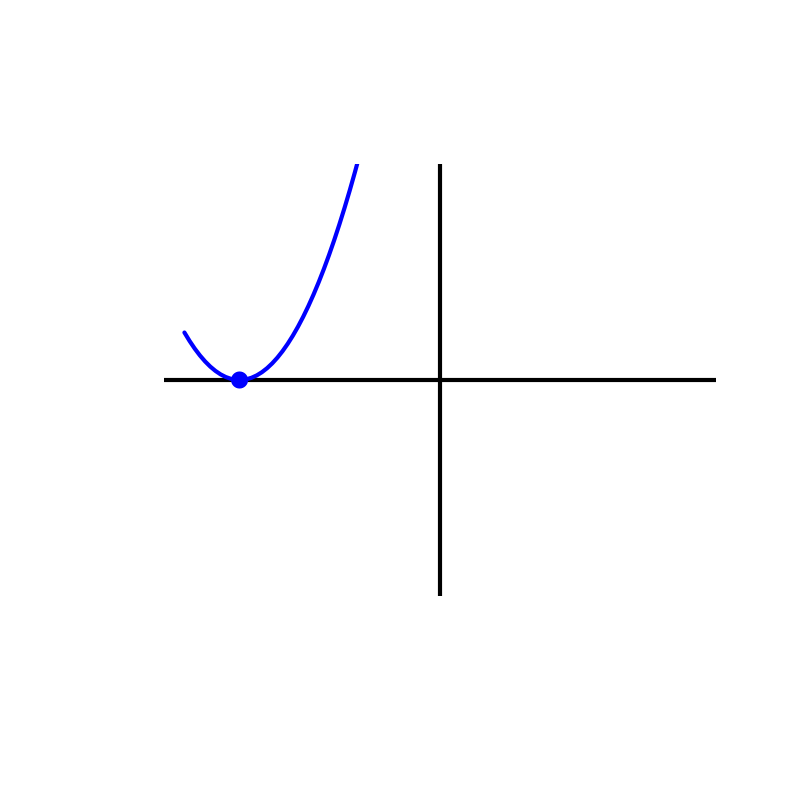

A standard-form quadratic function has three parameters $a$, $b$, and $c$:

$$y=ax^2+bx+c$$

When graphed, the quadratic function represents a parabola with a vertical axis of symmetry. The quadratic coefficient, $a$, represents the vertical stretch and orientation (whether the parabola opens upwards or downwards).

- If $a<0$, the parabola opens downwards, and the vertex is a maximum.
- If $a>0$, the parabola opens upwards, and the vertex is a minimum.

The constant term, $c$, represents the $y$-intercept. The linear coefficient, $b$, does not have a simple geometric interpretation. However, it is an essential part of some key formulas. For example, we have formulas for finding the vertex at $(h,k)$:

$$h=\frac{-b}{2a}$$

$$k=\frac{4ac-b^2}{4a}$$

Another important quantity we can calculate is the [discriminant](https://en.wikipedia.org/wiki/Quadratic_equation#Discriminant).

$$D~=~b^2-4ac$$

- If $D<0$, there are 0 $x$-intercepts.
- If $D=0$, there is 1 $x$-intercept, the vertex.
- If $D>0$, there are 2 $x$-intercepts.

A parabolic curve is defined with a quadratic function in standard form.

$$y~=~{-13}x^{2}-{12}x-{13}$$

- What is the parabola's orientation?
- Calculate $D$, the discriminant.
- How many $x$-intercepts does the curve have?
- Is the vertex left or right of the $y$ axis?
- Is the vertex above or below the $x$ axis?

Identify the coefficients.

$$a=-13$$
$$b=-12$$
$$c=-13$$

### Orientation

The quadratic coefficient, $a=-13$, is negative, so the parabola opens downward.

### Discriminant and number of roots

$$D=(-12)^2-4(-13)(-13)$$

$$D=-532$$

The discriminant, $D=-532$, is negative, so there are no $x$-intercepts.

### Vertex position

$$h=\frac{-(-12)}{2(-13)}$$

$$h=-0.4615385$$

The horizontal coordinate of the vertex, $h=-0.461538461538462$, is negative, so the vertex is to the left of the y axis.

$$k=\frac{4(-13)(-13)-(-12)^2}{4(-13)}$$

$$k=-10.2307692$$

The vertical coordinate of the vertex, $k=-10.2307692307692$, is negative, so the vertex is below of the x axis.

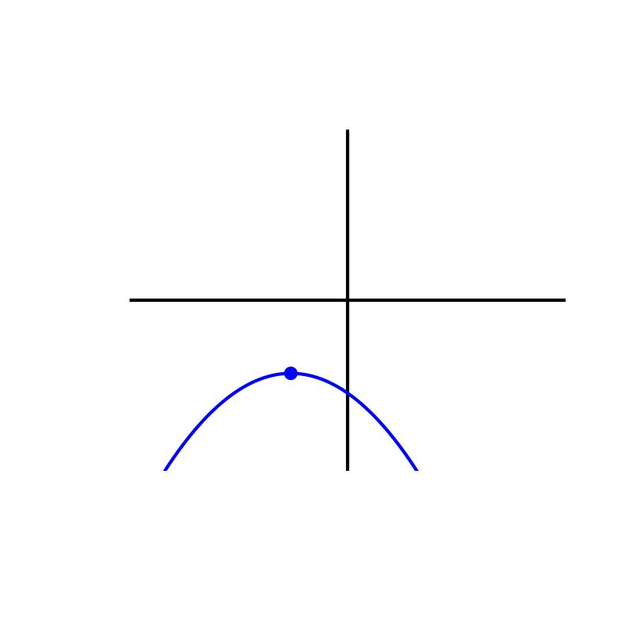

A standard-form quadratic function has three parameters $a$, $b$, and $c$:

$$y=ax^2+bx+c$$

When graphed, the quadratic function represents a parabola with a vertical axis of symmetry. The quadratic coefficient, $a$, represents the vertical stretch and orientation (whether the parabola opens upwards or downwards).

- If $a<0$, the parabola opens downwards, and the vertex is a maximum.
- If $a>0$, the parabola opens upwards, and the vertex is a minimum.

The constant term, $c$, represents the $y$-intercept. The linear coefficient, $b$, does not have a simple geometric interpretation. However, it is an essential part of some key formulas. For example, we have formulas for finding the vertex at $(h,k)$:

$$h=\frac{-b}{2a}$$

$$k=\frac{4ac-b^2}{4a}$$

Another important quantity we can calculate is the [discriminant](https://en.wikipedia.org/wiki/Quadratic_equation#Discriminant).

$$D~=~b^2-4ac$$

- If $D<0$, there are 0 $x$-intercepts.
- If $D=0$, there is 1 $x$-intercept, the vertex.
- If $D>0$, there are 2 $x$-intercepts.

A parabolic curve is defined with a quadratic function in standard form.

$$y~=~{3}x^{2}+{6}x+{3}$$

- What is the parabola's orientation?
- Calculate $D$, the discriminant.
- How many $x$-intercepts does the curve have?
- Is the vertex left or right of the $y$ axis?
- Is the vertex above or below the $x$ axis?

Identify the coefficients.

$$a=3$$
$$b=6$$
$$c=3$$

### Orientation

The quadratic coefficient, $a=3$, is positive, so the parabola opens upward.

### Discriminant and number of roots

$$D=(6)^2-4(3)(3)$$

$$D=0$$

The discriminant, $D=0$, is zero, so there is one $x$-intercept.

### Vertex position

$$h=\frac{-(6)}{2(3)}$$

$$h=-1$$

The horizontal coordinate of the vertex, $h=-1$, is negative, so the vertex is to the left of the y axis.

$$k=\frac{4(3)(3)-(6)^2}{4(3)}$$

$$k=0$$

The vertical coordinate of the vertex, $k=0$, is zero, so the vertex is on the x axis.

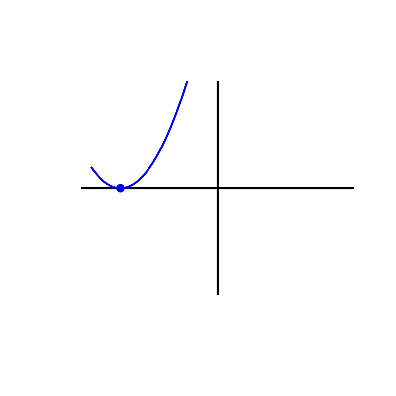

A standard-form quadratic function has three parameters $a$, $b$, and $c$:

$$y=ax^2+bx+c$$

When graphed, the quadratic function represents a parabola with a vertical axis of symmetry. The quadratic coefficient, $a$, represents the vertical stretch and orientation (whether the parabola opens upwards or downwards).

- If $a<0$, the parabola opens downwards, and the vertex is a maximum.
- If $a>0$, the parabola opens upwards, and the vertex is a minimum.

The constant term, $c$, represents the $y$-intercept. The linear coefficient, $b$, does not have a simple geometric interpretation. However, it is an essential part of some key formulas. For example, we have formulas for finding the vertex at $(h,k)$:

$$h=\frac{-b}{2a}$$

$$k=\frac{4ac-b^2}{4a}$$

Another important quantity we can calculate is the [discriminant](https://en.wikipedia.org/wiki/Quadratic_equation#Discriminant).

$$D~=~b^2-4ac$$

- If $D<0$, there are 0 $x$-intercepts.
- If $D=0$, there is 1 $x$-intercept, the vertex.
- If $D>0$, there are 2 $x$-intercepts.

A parabolic curve is defined with a quadratic function in standard form.

$$y~=~{4}x^{2}+{12}x+{9}$$

- What is the parabola's orientation?
- Calculate $D$, the discriminant.
- How many $x$-intercepts does the curve have?
- Is the vertex left or right of the $y$ axis?
- Is the vertex above or below the $x$ axis?

Identify the coefficients.

$$a=4$$
$$b=12$$
$$c=9$$

### Orientation

The quadratic coefficient, $a=4$, is positive, so the parabola opens upward.

### Discriminant and number of roots

$$D=(12)^2-4(4)(9)$$

$$D=0$$

The discriminant, $D=0$, is zero, so there is one $x$-intercept.

### Vertex position

$$h=\frac{-(12)}{2(4)}$$

$$h=-1.5$$

The horizontal coordinate of the vertex, $h=-1.5$, is negative, so the vertex is to the left of the y axis.

$$k=\frac{4(4)(9)-(12)^2}{4(4)}$$

$$k=0$$

The vertical coordinate of the vertex, $k=0$, is zero, so the vertex is on the x axis.

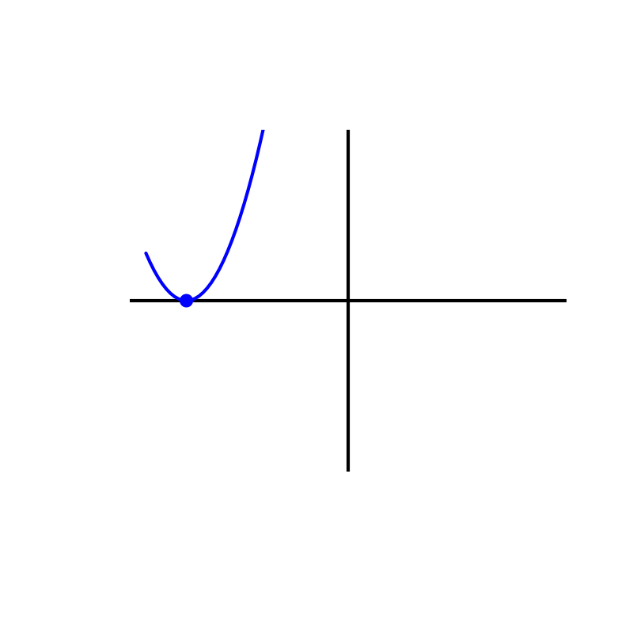

A standard-form quadratic function has three parameters $a$, $b$, and $c$:

$$y=ax^2+bx+c$$

When graphed, the quadratic function represents a parabola with a vertical axis of symmetry. The quadratic coefficient, $a$, represents the vertical stretch and orientation (whether the parabola opens upwards or downwards).

- If $a<0$, the parabola opens downwards, and the vertex is a maximum.
- If $a>0$, the parabola opens upwards, and the vertex is a minimum.

The constant term, $c$, represents the $y$-intercept. The linear coefficient, $b$, does not have a simple geometric interpretation. However, it is an essential part of some key formulas. For example, we have formulas for finding the vertex at $(h,k)$:

$$h=\frac{-b}{2a}$$

$$k=\frac{4ac-b^2}{4a}$$

Another important quantity we can calculate is the [discriminant](https://en.wikipedia.org/wiki/Quadratic_equation#Discriminant).

$$D~=~b^2-4ac$$

- If $D<0$, there are 0 $x$-intercepts.
- If $D=0$, there is 1 $x$-intercept, the vertex.
- If $D>0$, there are 2 $x$-intercepts.

A parabolic curve is defined with a quadratic function in standard form.

$$y~=~{13}x^{2}-x+{9}$$

- What is the parabola's orientation?
- Calculate $D$, the discriminant.
- How many $x$-intercepts does the curve have?
- Is the vertex left or right of the $y$ axis?
- Is the vertex above or below the $x$ axis?

Identify the coefficients.

$$a=13$$
$$b=-1$$
$$c=9$$

### Orientation

The quadratic coefficient, $a=13$, is positive, so the parabola opens upward.

### Discriminant and number of roots

$$D=(-1)^2-4(13)(9)$$

$$D=-467$$

The discriminant, $D=-467$, is negative, so there are no $x$-intercepts.

### Vertex position

$$h=\frac{-(-1)}{2(13)}$$

$$h=0.0384615$$

The horizontal coordinate of the vertex, $h=0.0384615384615385$, is positive, so the vertex is to the right of the y axis.

$$k=\frac{4(13)(9)-(-1)^2}{4(13)}$$

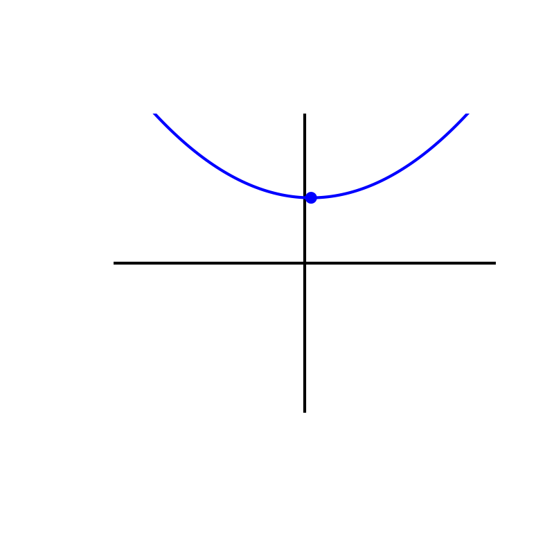

A standard-form quadratic function has three parameters $a$, $b$, and $c$:

$$y=ax^2+bx+c$$

When graphed, the quadratic function represents a parabola with a vertical axis of symmetry. The quadratic coefficient, $a$, represents the vertical stretch and orientation (whether the parabola opens upwards or downwards).

- If $a<0$, the parabola opens downwards, and the vertex is a maximum.
- If $a>0$, the parabola opens upwards, and the vertex is a minimum.

The constant term, $c$, represents the $y$-intercept. The linear coefficient, $b$, does not have a simple geometric interpretation. However, it is an essential part of some key formulas. For example, we have formulas for finding the vertex at $(h,k)$:

$$h=\frac{-b}{2a}$$

$$k=\frac{4ac-b^2}{4a}$$

Another important quantity we can calculate is the [discriminant](https://en.wikipedia.org/wiki/Quadratic_equation#Discriminant).

$$D~=~b^2-4ac$$

- If $D<0$, there are 0 $x$-intercepts.
- If $D=0$, there is 1 $x$-intercept, the vertex.
- If $D>0$, there are 2 $x$-intercepts.

A parabolic curve is defined with a quadratic function in standard form.

$$y~=~{7}x^{2}-{14}x+{7}$$

- What is the parabola's orientation?
- Calculate $D$, the discriminant.
- How many $x$-intercepts does the curve have?
- Is the vertex left or right of the $y$ axis?
- Is the vertex above or below the $x$ axis?

Identify the coefficients.

$$a=7$$
$$b=-14$$
$$c=7$$

### Orientation

The quadratic coefficient, $a=7$, is positive, so the parabola opens upward.

### Discriminant and number of roots

$$D=(-14)^2-4(7)(7)$$

$$D=0$$

The discriminant, $D=0$, is zero, so there is one $x$-intercept.

### Vertex position

$$h=\frac{-(-14)}{2(7)}$$

$$h=1$$

The horizontal coordinate of the vertex, $h=1$, is positive, so the vertex is to the right of the y axis.

$$k=\frac{4(7)(7)-(-14)^2}{4(7)}$$

$$k=0$$

The vertical coordinate of the vertex, $k=0$, is zero, so the vertex is on the x axis.

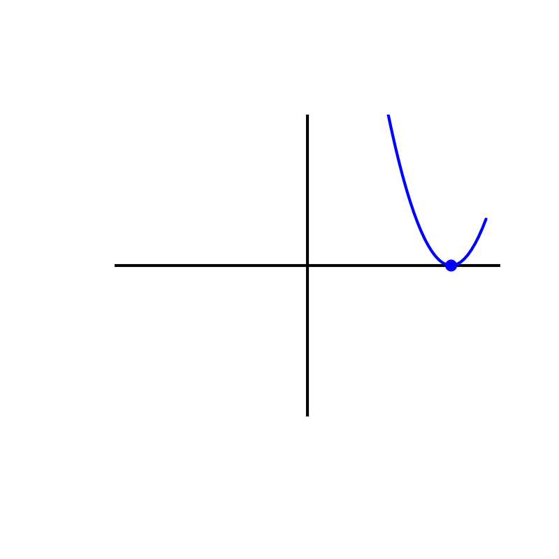